# Teoría de la Desición-Trabajo 2

Maria Rosario Ruiz Ávila

11/20/2024

# Problema: Selección de Ubicación para una Nueva Discoteca

Un empresario desea abrir una nueva discoteca en una ciudad. Para seleccionar la mejor ubicación entre cinco opciones, se han definido los siguientes criterios con sus respectivos pesos:

## Criterios para Selección de Ubicación

1. **Proximidad a zonas residenciales jóvenes (3 puntos)**: Es importante que la discoteca esté cerca de zonas habitadas por personas jóvenes, quienes son el público objetivo principal.
2. **Accesibilidad (2,5 puntos)**: La ubicación debe contar con buenas conexiones de transporte público, carreteras y aparcamientos cercanos.
3. **Costo del alquiler mensual (2 puntos)**: Aunque un lugar estratégico es importante, el costo del alquiler no debe superar el presupuesto.
4. **Competencia cercana (2 puntos)**: Menos competencia en la zona incrementa la probabilidad de éxito.
5. **Tamaño del local (2 puntos)**: La discoteca necesita espacio suficiente para acomodar a los clientes y ofrecer áreas de baile, mesas y barras.

## Opciones de Ubicación

A continuación se presentan las cinco opciones disponibles, con las puntuaciones respectivas para cada criterio.

| **Ubicación** | **Proximidad a zonas residenciales jóvenes** | **Accesibilidad** | **Costo del alquiler mensual** | **Competencia cercana** | **Tamaño del local** |
| --- | --- | --- | --- | --- | --- |
| **A** | 80 puntos | 70 puntos | 6,000 €/mes | 60 puntos | 300 m² |
| **B** | 70 puntos | 85 puntos | 5,500 €/mes | 80 puntos | 250 m² |
| **C** | 90 puntos | 65 puntos | 7,000 €/mes | 50 puntos | 320 m² |
| **D** | 75 puntos | 80 puntos | 6,500 €/mes | 70 puntos | 270 m² |
| **E** | 65 puntos | 90 puntos | 4,500 €/mes | 85 puntos | 230 m² |

```r
library(htmltools)
library(shape)
library(pander)
source("teoriadecision_funciones_multicriterio.R")
source("teoriadecision_funciones_multicriterio_diagram.R")
source("teoriadecision_funciones_multicriterio_utiles.R")
source("teoriadecision_funciones_incertidumbre.R")
```

Definimos los criterios:

```r
criterios = c(
  "Proximidad a zonas residenciales jóvenes",
  "Accesibilidad",
  "Costo del alquiler mensual",
  "Competencia cercana",
  "Tamaño del local"
)

# Si el objetivo es maximizar o minimizar
min_max = c("Max", "Max", "Min", "Min", "Max")
```

Definimos las alternativas:

```r
alternativas = c("Ubicación A", "Ubicación B", "Ubicación C", "Ubicación D", "Ubicación E")

# Puntuaciones de cada alternativa
Ubicacion_A = c(80, 70, 6000, 60, 300)
Ubicacion_B = c(70, 85, 5500, 80, 250)
Ubicacion_C = c(90, 65, 7000, 50, 320)
Ubicacion_D = c(75, 80, 6500, 70, 270)
Ubicacion_E = c(65, 90, 4500, 85, 230)
```

Definimos pesos, idealidad y referencia de los criterios:

```r
# Pesos de los criterios
p = c(3, 2.5, 2, 2, 2)

# Idealidad de los valores
q = c(1, 1, 0, 0, 1) # Max=1, Min=0

# Referencia de los criterios
s = c(100, 100, 4000, 100, 400)
```

Creamos la tabla:

```r
tabla= data.frame(
  "Criterios" = criterios,
  "Min/Max" = min_max,
  Ubicacion_A, Ubicacion_B, Ubicacion_C, Ubicacion_D, Ubicacion_E,
  "Pesos" = p, "Idealidad" = q, "Referencia" = s
)
pander(tabla)
```

Table continues below

| Criterios | Min.Max | Ubicacion_A | Ubicacion_B | Ubicacion_C |
| --- | --- | --- | --- | --- |
| Proximidad a zonas residenciales jóvenes | Max | 80 | 70 | 90 |
| Accesibilidad | Max | 70 | 85 | 65 |
| Costo del alquiler mensual | Min | 6000 | 5500 | 7000 |
| Competencia cercana | Min | 60 | 80 | 50 |
| Tamaño del local | Max | 300 | 250 | 320 |

| Ubicacion_D | Ubicacion_E | Pesos | Idealidad | Referencia |
| --- | --- | --- | --- | --- |
| 75 | 65 | 3 | 1 | 100 |
| 80 | 90 | 2.5 | 1 | 100 |
| 6500 | 4500 | 2 | 0 | 4000 |
| 70 | 85 | 2 | 0 | 100 |
| 270 | 230 | 2 | 1 | 400 |

Creamos la matriz de desición:

```r
desicion=multicriterio.crea.matrizdecision(c(80, 70, -6000, -60, 300,
                                             70, 85, -5500, -80, 250,
                                             90, 65, -7000, -50, 320,
                                             75, 80, -6500, -70, 270,
                                             65, 90, -4500, -85, 230),
                                           numalternativas = 5,
                                           numcriterios = 5,
                                           v.nombresalt = alternativas,
                                           v.nombrescri = criterios

)
```

#MÉTODO PROMETHEE I

```r
# Cargar las bibliotecas necesarias
library(qgraph)

# Crear la tabla de preferencias ajustada para la discoteca
preferencias = matrix(c(
  1, 1, 3, 100,    # Proximidad a zonas residenciales jóvenes (Tipo 1: Usual)
  5, 1, 2.5, 100,  # Accesibilidad (Tipo 5: Lineal)
  5, 0, 2, 4000,   # Costo del alquiler mensual (Tipo 5: Lineal)
  1, 0, 2, 100,    # Competencia cercana (Tipo 1: Usual)
  5, 1, 2, 400     # Tamaño del local (Tipo 5: Lineal)
), ncol = 4, byrow = TRUE)

# Calcular los pesos normalizados para PROMETHEE
pesos = preferencias[, 3] / sum(preferencias[, 3])

# Aplicar el método PROMETHEE I
promethee_i =multicriterio.metodo.promethee_i(
  desicion,
  pesos.criterios = pesos,
  tab.fpref = preferencias
)
promethee_i
```

```
## $tabla.indices
##             Ubicación A Ubicación B Ubicación C Ubicación D Ubicación E
## Ubicación A   0.0000000   0.6086957   0.3913043   0.7826087   0.6086957
## Ubicación B   0.3913043   0.0000000   0.3913043   0.3913043   0.6086957
## Ubicación C   0.6086957   0.6086957   0.0000000   0.6086957   0.6086957
## Ubicación D   0.2173913   0.6086957   0.3913043   0.0000000   0.6086957
## Ubicación E   0.3913043   0.3913043   0.3913043   0.3913043   0.0000000
##
## $vflujos.ent
## Ubicación A Ubicación B Ubicación C Ubicación D Ubicación E
##    2.391304    1.782609    2.434783    1.826087    1.565217
##
## $vflujos.sal
## Ubicación A Ubicación B Ubicación C Ubicación D Ubicación E
##    1.608696    2.217391    1.565217    2.173913    2.434783
##
## $tablarelacionsupera
##             Ubicación A Ubicación B Ubicación C Ubicación D Ubicación E
## Ubicación A         0.5         1.0         0.0         1.0         1.0
## Ubicación B         0.0         0.5         0.0         0.0         1.0
## Ubicación C         1.0         1.0         0.5         1.0         1.0
## Ubicación D         0.0         1.0         0.0         0.5         1.0
## Ubicación E         0.0         0.0         0.0         0.0         0.5
```

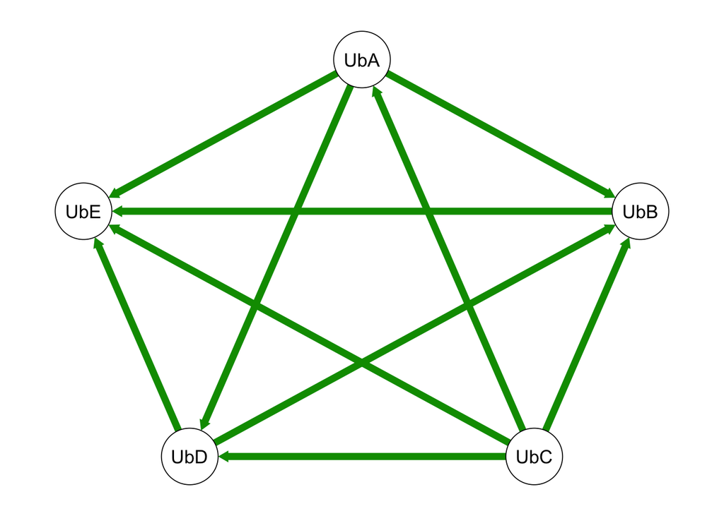

```r
# Graficar las relaciones de superación usando qgraph
qgraph::qgraph(promethee_i$tablarelacionsupera)
```

La mejor alternativa es la opción C ya que esa alternativa supera a las demás.

#MÉTODO PROMETHEE II

```r
promethee_ii = multicriterio.metodo.promethee_ii(desicion, pesos.criterios =pesos,
tab.fpref = preferencias)
promethee_ii
```

```
## $tabla.indices
##             Ubicación A Ubicación B Ubicación C Ubicación D Ubicación E
## Ubicación A   0.0000000   0.6086957   0.3913043   0.7826087   0.6086957
## Ubicación B   0.3913043   0.0000000   0.3913043   0.3913043   0.6086957
## Ubicación C   0.6086957   0.6086957   0.0000000   0.6086957   0.6086957
## Ubicación D   0.2173913   0.6086957   0.3913043   0.0000000   0.6086957
## Ubicación E   0.3913043   0.3913043   0.3913043   0.3913043   0.0000000
##
## $vflujos.netos
## Ubicación A Ubicación B Ubicación C Ubicación D Ubicación E
##   0.7826087  -0.4347826   0.8695652  -0.3478261  -0.8695652
##
## $tablarelacionsupera
##             Ubicación A Ubicación B Ubicación C Ubicación D Ubicación E
## Ubicación A         0.5         1.0         0.0         1.0         1.0
## Ubicación B         0.0         0.5         0.0         0.0         1.0
## Ubicación C         1.0         1.0         0.5         1.0         1.0
## Ubicación D         0.0         1.0         0.0         0.5         1.0
## Ubicación E         0.0         0.0         0.0         0.0         0.5
```

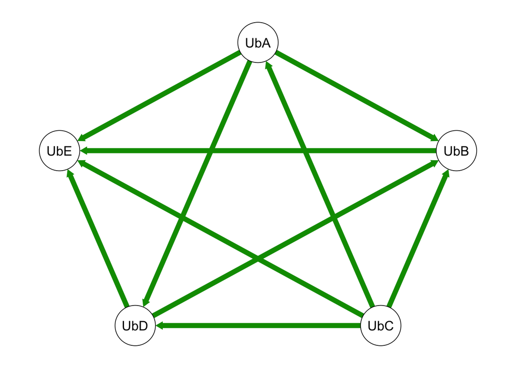

```r
qgraph::qgraph(promethee_ii$tablarelacionsupera)
```

En este caso, la alternativa C sigue siendo la mejor ubicación para la discoteca, teniendo el mayor flujo neto y viendo que en la tabla supera la ubicación C tiene 1 en todas las columnas comparativas con el resto de ubicaciones.

```r
order(promethee_ii$vflujos.netos,decreasing = T)
```

```
## [1] 3 1 4 2 5
```

Podemos ver que es la tercera ubicación la mejor.

# Metodo I medias

```r
medias_i = multicriterio.metodo.promethee_i_med(desicion,
 pesos.criterios = pesos,tab.fpref = preferencias)
medias_i
```

```
## $tabla.indices
##             Ubicación A Ubicación B Ubicación C Ubicación D Ubicación E
## Ubicación A   0.0000000   0.6086957   0.3913043   0.7826087   0.6086957
## Ubicación B   0.3913043   0.0000000   0.3913043   0.3913043   0.6086957
## Ubicación C   0.6086957   0.6086957   0.0000000   0.6086957   0.6086957
## Ubicación D   0.2173913   0.6086957   0.3913043   0.0000000   0.6086957
## Ubicación E   0.3913043   0.3913043   0.3913043   0.3913043   0.0000000
##
## $vflujos.ent
## Ubicación A Ubicación B Ubicación C Ubicación D Ubicación E
##   0.5978261   0.4456522   0.6086957   0.4565217   0.3913043
##
## $vflujos.sal
## Ubicación A Ubicación B Ubicación C Ubicación D Ubicación E
##   0.4021739   0.5543478   0.3913043   0.5434783   0.6086957
##
## $tablarelacionsupera
##             Ubicación A Ubicación B Ubicación C Ubicación D Ubicación E
## Ubicación A           0           1           0           1           1
## Ubicación B           0           0           0           0           1
## Ubicación C           1           1           0           1           1
## Ubicación D           0           1           0           0           1
## Ubicación E           0           0           0           0           0
```

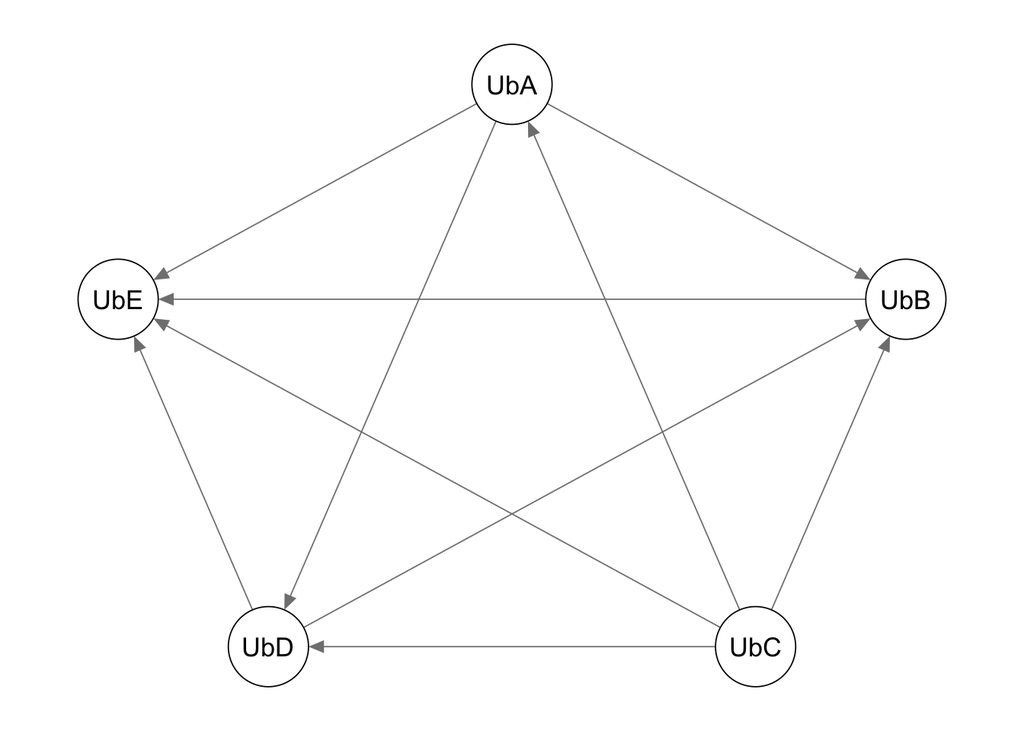

```r
qgraph::qgraph(medias_i$tablarelacionsupera)
```

```r
pesos.criterios =pesos
```

También la mejor alternativa es la C, vemos que en la tabla supera la fila C con respecto a todas las otras ubicaciones es 1 por lo que supera a todas.

# Metodo II medias

```r
medias_ii = multicriterio.metodo.promethee_ii_med(desicion,pesos.criterios=pesos,
                                                  tab.fpref = preferencias)
medias_ii
```

```
## $tabla.indices
##             Ubicación A Ubicación B Ubicación C Ubicación D Ubicación E
## Ubicación A   0.0000000   0.6086957   0.3913043   0.7826087   0.6086957
## Ubicación B   0.3913043   0.0000000   0.3913043   0.3913043   0.6086957
## Ubicación C   0.6086957   0.6086957   0.0000000   0.6086957   0.6086957
## Ubicación D   0.2173913   0.6086957   0.3913043   0.0000000   0.6086957
## Ubicación E   0.3913043   0.3913043   0.3913043   0.3913043   0.0000000
##
## $vflujos.netos
## Ubicación A Ubicación B Ubicación C Ubicación D Ubicación E
##  0.19565217 -0.10869565  0.21739130 -0.08695652 -0.21739130
##
## $tablarelacionsupera
##             Ubicación A Ubicación B Ubicación C Ubicación D Ubicación E
## Ubicación A           0           1           0           1           1
## Ubicación B           0           0           0           0           1
## Ubicación C           1           1           0           1           1
## Ubicación D           0           1           0           0           1
## Ubicación E           0           0           0           0           0
```

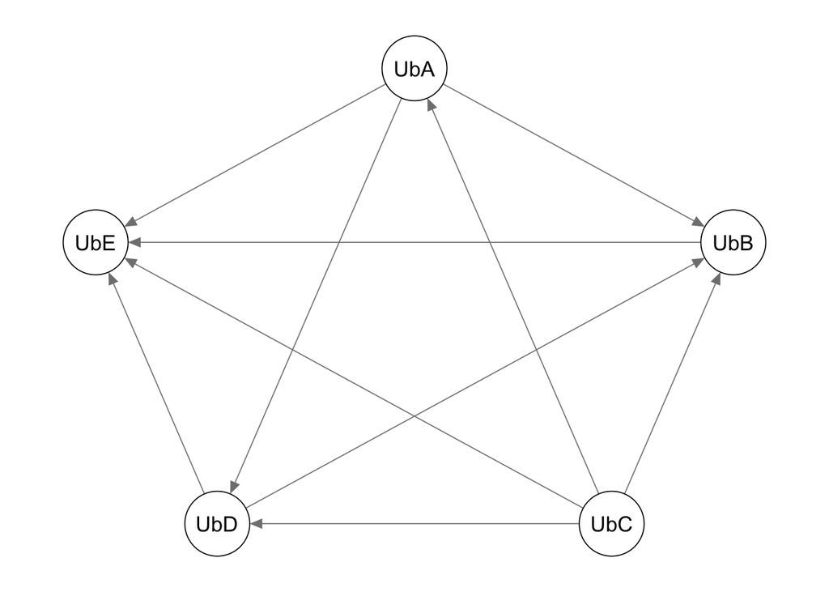

```r
qgraph::qgraph(medias_ii$tablarelacionsupera)
```

```r
order(medias_ii$vflujos.netos,decreasing = T)
```

```
## [1] 3 1 4 2 5
```

La tercera alternativa sigue siendo la mejor también en este método.

# METODO ELECTRE:

```r
electre_1= multicriterio.metodoELECTRE_I(desicion,
                                      pesos.criterios = pesos,
                                      nivel.concordancia.minimo.alpha = 0.7,
                                      no.se.compensan =c(Inf, Inf, Inf, Inf, Inf),
                                      que.alternativas = T)
electre_1
```

```
## $datos
##                 Proximidad a zonas residenciales jóvenes Accesibilidad
## Ubicación A                                   80.0000000    70.0000000
## Ubicación B                                   70.0000000    85.0000000
## Ubicación C                                   90.0000000    65.0000000
## Ubicación D                                   75.0000000    80.0000000
## Ubicación E                                   65.0000000    90.0000000
## pesos.criterios                                0.2608696     0.2173913
## no.se.compensan                                      Inf           Inf
##                 Costo del alquiler mensual Competencia cercana Tamaño del local
## Ubicación A                   -6000.000000          -60.000000       300.000000
## Ubicación B                   -5500.000000          -80.000000       250.000000
## Ubicación C                   -7000.000000          -50.000000       320.000000
## Ubicación D                   -6500.000000          -70.000000       270.000000
## Ubicación E                   -4500.000000          -85.000000       230.000000
## pesos.criterios                   0.173913            0.173913         0.173913
## no.se.compensan                        Inf                 Inf              Inf
##
## $alpha
## [1] 0.7
##
## $Imas
## , , Proximidad a zonas residenciales jóvenes
##
##             Ubicación A Ubicación B Ubicación C Ubicación D Ubicación E
## Ubicación A       FALSE        TRUE       FALSE        TRUE        TRUE
## Ubicación B       FALSE       FALSE       FALSE       FALSE        TRUE
## Ubicación C        TRUE        TRUE       FALSE        TRUE        TRUE
## Ubicación D       FALSE        TRUE       FALSE       FALSE        TRUE
## Ubicación E       FALSE       FALSE       FALSE       FALSE       FALSE
##
## , , Accesibilidad
##
##             Ubicación A Ubicación B Ubicación C Ubicación D Ubicación E
## Ubicación A       FALSE       FALSE        TRUE       FALSE       FALSE
## Ubicación B        TRUE       FALSE        TRUE        TRUE       FALSE
## Ubicación C       FALSE       FALSE       FALSE       FALSE       FALSE
## Ubicación D        TRUE       FALSE        TRUE       FALSE       FALSE
## Ubicación E        TRUE        TRUE        TRUE        TRUE       FALSE
##
```

[output cut: 150 more lines]

```
## Ubicación C        TRUE        TRUE        TRUE        TRUE        TRUE
## Ubicación D        TRUE        TRUE        TRUE        TRUE        TRUE
## Ubicación E        TRUE        TRUE        TRUE        TRUE        TRUE
##
## $relacion.dominante
##             Ubicación A Ubicación B Ubicación C Ubicación D Ubicación E
## Ubicación A       FALSE       FALSE       FALSE        TRUE       FALSE
## Ubicación B       FALSE       FALSE       FALSE       FALSE       FALSE
## Ubicación C       FALSE       FALSE       FALSE       FALSE       FALSE
## Ubicación D       FALSE       FALSE       FALSE       FALSE       FALSE
## Ubicación E       FALSE       FALSE       FALSE       FALSE       FALSE
##
## $nucleo_aprox
## Ubicación A Ubicación B Ubicación C Ubicación E
##           1           2           3           5
```

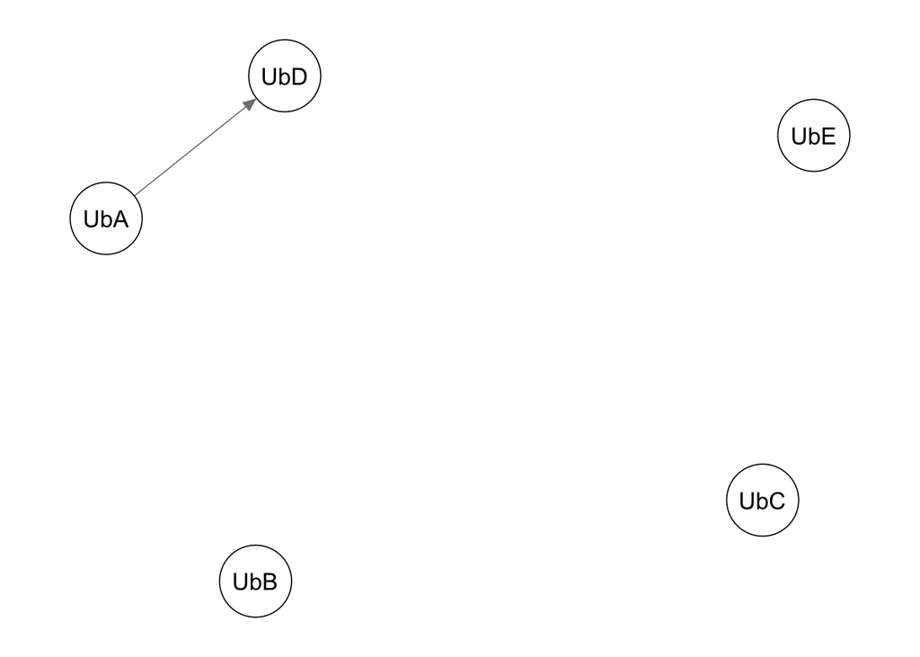

```r
library(qgraph)
qgraph::qgraph(electre_1$relacion.dominante)
```

En principio, no notamos cuál va a ser la mejor solución por lo que vamos a reducir el alpha para sacar mejores conclusiones:

```r
electre_reducido = multicriterio.metodoELECTRE_I(desicion,
                                      pesos.criterios = pesos,
                                      nivel.concordancia.minimo.alpha = 0.6,
                                     no.se.compensan =c(Inf, Inf, Inf, Inf, Inf) ,
                                      que.alternativas = c(1,2,3,5))
electre_reducido
```

```
## $datos
##                 Proximidad a zonas residenciales jóvenes Accesibilidad
## Ubicación A                                   80.0000000    70.0000000
## Ubicación B                                   70.0000000    85.0000000
## Ubicación C                                   90.0000000    65.0000000
## Ubicación E                                   65.0000000    90.0000000
## pesos.criterios                                0.2608696     0.2173913
## no.se.compensan                                      Inf           Inf
##                 Costo del alquiler mensual Competencia cercana Tamaño del local
## Ubicación A                   -6000.000000          -60.000000       300.000000
## Ubicación B                   -5500.000000          -80.000000       250.000000
## Ubicación C                   -7000.000000          -50.000000       320.000000
## Ubicación E                   -4500.000000          -85.000000       230.000000
## pesos.criterios                   0.173913            0.173913         0.173913
## no.se.compensan                        Inf                 Inf              Inf
##
## $alpha
## [1] 0.6
##
## $Imas
## , , Proximidad a zonas residenciales jóvenes
##
##             Ubicación A Ubicación B Ubicación C Ubicación E
## Ubicación A       FALSE        TRUE       FALSE        TRUE
## Ubicación B       FALSE       FALSE       FALSE        TRUE
## Ubicación C        TRUE        TRUE       FALSE        TRUE
## Ubicación E       FALSE       FALSE       FALSE       FALSE
##
## , , Accesibilidad
##
##             Ubicación A Ubicación B Ubicación C Ubicación E
## Ubicación A       FALSE       FALSE        TRUE       FALSE
## Ubicación B        TRUE       FALSE        TRUE       FALSE
## Ubicación C       FALSE       FALSE       FALSE       FALSE
## Ubicación E        TRUE        TRUE        TRUE       FALSE
##
## , , Costo del alquiler mensual
##
##             Ubicación A Ubicación B Ubicación C Ubicación E
## Ubicación A       FALSE       FALSE        TRUE       FALSE
```

[output cut: 128 more lines]

```
## Ubicación A        TRUE        TRUE        TRUE        TRUE
## Ubicación B        TRUE        TRUE        TRUE        TRUE
## Ubicación C        TRUE        TRUE        TRUE        TRUE
## Ubicación E        TRUE        TRUE        TRUE        TRUE
##
## $relacion.dominante
##             Ubicación A Ubicación B Ubicación C Ubicación E
## Ubicación A       FALSE        TRUE       FALSE        TRUE
## Ubicación B       FALSE       FALSE       FALSE        TRUE
## Ubicación C        TRUE        TRUE       FALSE        TRUE
## Ubicación E       FALSE       FALSE       FALSE       FALSE
##
## $nucleo_aprox
## Ubicación C
##           3
```

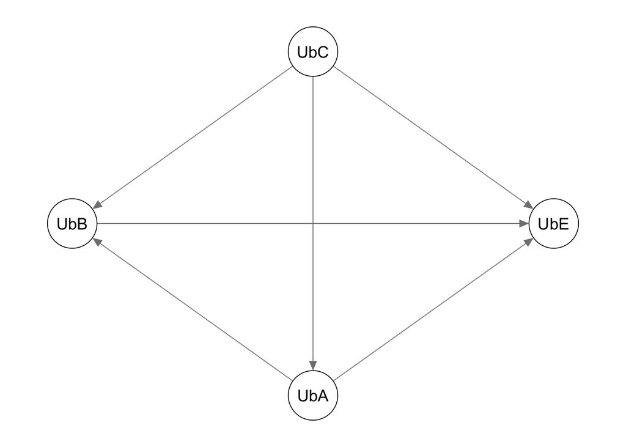

```r
qgraph::qgraph(electre_reducido$relacion.dominante)
```

Aquí podemos observar que tenemos ahora solo 4 ubicaciones, vamos a seguir reduciendo para sacar la mejor conclusión:

```r
electre_reducido2 = multicriterio.metodoELECTRE_I(desicion,
                                      pesos.criterios = pesos,
                                      nivel.concordancia.minimo.alpha = 0.51,
                                     no.se.compensan = c(Inf, Inf, Inf, Inf, Inf),
                                      que.alternativas = c(1,3,4))
electre_reducido2
```

```
## $datos
##                 Proximidad a zonas residenciales jóvenes Accesibilidad
## Ubicación A                                   80.0000000    70.0000000
## Ubicación C                                   90.0000000    65.0000000
## Ubicación D                                   75.0000000    80.0000000
## pesos.criterios                                0.2608696     0.2173913
## no.se.compensan                                      Inf           Inf
##                 Costo del alquiler mensual Competencia cercana Tamaño del local
## Ubicación A                   -6000.000000          -60.000000       300.000000
## Ubicación C                   -7000.000000          -50.000000       320.000000
## Ubicación D                   -6500.000000          -70.000000       270.000000
## pesos.criterios                   0.173913            0.173913         0.173913
## no.se.compensan                        Inf                 Inf              Inf
##
## $alpha
## [1] 0.51
##
## $Imas
## , , Proximidad a zonas residenciales jóvenes
##
##             Ubicación A Ubicación C Ubicación D
## Ubicación A       FALSE       FALSE        TRUE
## Ubicación C        TRUE       FALSE        TRUE
## Ubicación D       FALSE       FALSE       FALSE
##
## , , Accesibilidad
##
##             Ubicación A Ubicación C Ubicación D
## Ubicación A       FALSE        TRUE       FALSE
## Ubicación C       FALSE       FALSE       FALSE
## Ubicación D        TRUE        TRUE       FALSE
##
## , , Costo del alquiler mensual
##
##             Ubicación A Ubicación C Ubicación D
## Ubicación A       FALSE        TRUE        TRUE
## Ubicación C       FALSE       FALSE       FALSE
## Ubicación D       FALSE        TRUE       FALSE
##
## , , Competencia cercana
```

[output cut: 106 more lines]

```
## $test.discordancia
##             Ubicación A Ubicación C Ubicación D
## Ubicación A        TRUE        TRUE        TRUE
## Ubicación C        TRUE        TRUE        TRUE
## Ubicación D        TRUE        TRUE        TRUE
##
## $relacion.dominante
##             Ubicación A Ubicación C Ubicación D
## Ubicación A       FALSE       FALSE        TRUE
## Ubicación C        TRUE       FALSE        TRUE
## Ubicación D       FALSE       FALSE       FALSE
##
## $nucleo_aprox
## Ubicación C
##           2
```

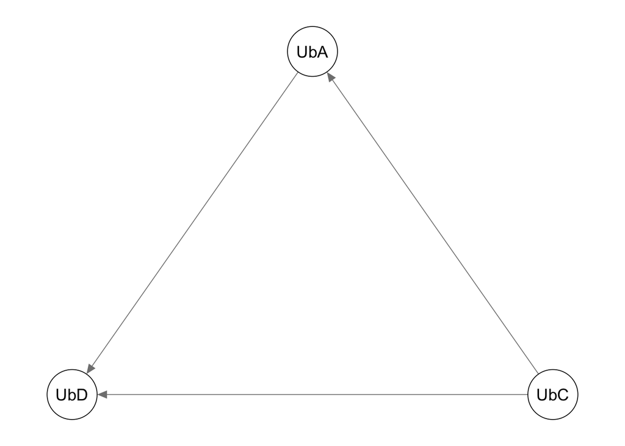

```r
qgraph::qgraph(electre_reducido2$relacion.dominante)
```

Podemos concluir que la mejor solución es la misma que en los otros métodos, la ubicación C seguida de la ubicación A.

# METODO AHP

Matrices de Comparación para las Alternativas respecto a Cada Criterio

Escala de Importancia (AHP)

1: Igualmente importante.

3: Moderadamente más importante.

5: Mucho más importante.

7: Muy fuertemente más importante.

9: Extremadamente más importante.

Recíprocos: Los valores inversos (1/3, 1/5, etc.) se usan para las relaciones inversas.

```r
proximidad =  matrix(c(
  1,   5,   1/5,  3,  7,   # A vs B, C, D, E
  1/5, 1,   1/7,  1/3,  3,   # B vs A, C, D, E
  5,   7,   1,   5,    9,   # C vs A, B, D, E
  1/3,   3,   1/5, 1,    5,   # D vs A, B, C, E
  1/7, 1/3, 1/9, 1/5,  1    # E vs A, B, C, D
), nrow = 5, byrow = TRUE)
rownames(proximidad) = c("A", "B", "C", "D", "E")
colnames(proximidad) = c("A", "B", "C", "D", "E")
library(kableExtra)
kable(proximidad, caption = "Matriz de Comparación: Proximidad a Zonas Residenciales Jóvenes")
```

Matriz de Comparación: Proximidad a Zonas Residenciales Jóvenes

|  | A | B | C | D | E |
| --- | --- | --- | --- | --- | --- |
| A | 1.0000000 | 5.0000000 | 0.2000000 | 3.0000000 | 7 |
| B | 0.2000000 | 1.0000000 | 0.1428571 | 0.3333333 | 3 |
| C | 5.0000000 | 7.0000000 | 1.0000000 | 5.0000000 | 9 |
| D | 0.3333333 | 3.0000000 | 0.2000000 | 1.0000000 | 5 |
| E | 0.1428571 | 0.3333333 | 0.1111111 | 0.2000000 | 1 |

```r
accesibilidad=  matrix(c(
  1,   1/5, 3,   1/3,   1/5,   # Comparaciones entre ubicaciones (A vs B, C, D, E)
  5,   1,   7,   3,   1/3,   # B
  1/3, 1/7, 1,   1/5, 1/9, # C
  3, 1/3, 5,   1,   1/7,   # D
  5, 3, 9,   7, 1    # E
), nrow = 5, byrow = TRUE)


rownames(accesibilidad) = c("A", "B", "C", "D", "E")
colnames(accesibilidad) = c("A", "B", "C", "D", "E")
kable(accesibilidad, caption = "Matriz de Comparación: Accesibilidad")
```

Matriz de Comparación: Accesibilidad

|  | A | B | C | D | E |
| --- | --- | --- | --- | --- | --- |
| A | 1.0000000 | 0.2000000 | 3 | 0.3333333 | 0.2000000 |
| B | 5.0000000 | 1.0000000 | 7 | 3.0000000 | 0.3333333 |
| C | 0.3333333 | 0.1428571 | 1 | 0.2000000 | 0.1111111 |
| D | 3.0000000 | 0.3333333 | 5 | 1.0000000 | 0.1428571 |
| E | 5.0000000 | 3.0000000 | 9 | 7.0000000 | 1.0000000 |

```r
costo = matrix(c(
  1,   3,   1/3,  1/3,   5,
  1/3,   1,   1/5,   1/5,   5,
  3, 5, 1,   3,   9,
  3, 5, 1/3,   1,   7,
  1/5, 1/5, 1/9, 1/7, 1
), nrow = 5, byrow = TRUE)




rownames(costo) = c("A", "B", "C", "D", "E")
colnames(costo) = c("A", "B", "C", "D", "E")
kable(costo, caption = "Matriz de Comparación: Costo del Alquiler Mensual")
```

Matriz de Comparación: Costo del Alquiler Mensual

|  | A | B | C | D | E |
| --- | --- | --- | --- | --- | --- |
| A | 1.0000000 | 3.0 | 0.3333333 | 0.3333333 | 5 |
| B | 0.3333333 | 1.0 | 0.2000000 | 0.2000000 | 5 |
| C | 3.0000000 | 5.0 | 1.0000000 | 3.0000000 | 9 |
| D | 3.0000000 | 5.0 | 0.3333333 | 1.0000000 | 7 |
| E | 0.2000000 | 0.2 | 0.1111111 | 0.1428571 | 1 |

```r
competencia =  matrix(c(
  1,   1/5,   3,   1/3,   1/7,
  5,   1,   9,   3,   1/3,
  1/3, 1/9, 1,   1/7,   1/9,
  3, 1/3, 7,   1,   1/5,
  7, 3, 9, 5, 1
), nrow = 5, byrow = TRUE)

rownames(competencia) = c("A", "B", "C", "D", "E")
colnames(competencia) = c("A", "B", "C", "D", "E")
kable(competencia, caption = "Matriz de Comparación: Competencia Cercana")
```

Matriz de Comparación: Competencia Cercana

|  | A | B | C | D | E |
| --- | --- | --- | --- | --- | --- |
| A | 1.0000000 | 0.2000000 | 3 | 0.3333333 | 0.1428571 |
| B | 5.0000000 | 1.0000000 | 9 | 3.0000000 | 0.3333333 |
| C | 0.3333333 | 0.1111111 | 1 | 0.1428571 | 0.1111111 |
| D | 3.0000000 | 0.3333333 | 7 | 1.0000000 | 0.2000000 |
| E | 7.0000000 | 3.0000000 | 9 | 5.0000000 | 1.0000000 |

```r
tamano = matrix(c(
  1,5,  1/3,  3,  7,
  1/3, 1, 1/5, 1/3,3,
  3,5, 1, 5,9,
  1/3,3, 1/5,  1,5,
  1/7,1/9,1/5, 1/5, 1
), nrow = 5, byrow = TRUE)

rownames(tamano) = c("A", "B", "C", "D", "E")
colnames(tamano) = c("A", "B", "C", "D", "E")
kable(tamano, caption = "Matriz de Comparación: Tamaño del Local")
```

Matriz de Comparación: Tamaño del Local

|  | A | B | C | D | E |
| --- | --- | --- | --- | --- | --- |
| A | 1.0000000 | 5.0000000 | 0.3333333 | 3.0000000 | 7 |
| B | 0.3333333 | 1.0000000 | 0.2000000 | 0.3333333 | 3 |
| C | 3.0000000 | 5.0000000 | 1.0000000 | 5.0000000 | 9 |
| D | 0.3333333 | 3.0000000 | 0.2000000 | 1.0000000 | 5 |
| E | 0.1428571 | 0.1111111 | 0.2000000 | 0.2000000 | 1 |

Matriz de Comparación por Pares de los Criterios:

```r
criterios2 =matrix(c(
  1,   3,   5,   5,   5,   # Proximidad vs. otros criterios
  1/3, 1,   3,   3,   3,   # Accesibilidad vs. otros criterios
  1/5, 1/3, 1,   1,   1,   # Costo vs. otros criterios
  1/5, 1/3, 1,   1,   1,   # Competencia vs. otros criterios
  1/5, 1/3, 1,   1,   1    # Tamaño vs. otros criterios
), nrow = 5, byrow = TRUE)

rownames(criterios2) = c("Proximidad", "Accesibilidad", "Costo", "Competencia", "Tamaño")
colnames(criterios2) = c("Proximidad", "Accesibilidad", "Costo", "Competencia", "Tamaño")
kable(criterios2, caption = "Matriz de Comparación por Pares de los Criterios")
```

Matriz de Comparación por Pares de los Criterios

|  | Proximidad | Accesibilidad | Costo | Competencia | Tamaño |
| --- | --- | --- | --- | --- | --- |
| Proximidad | 1.0000000 | 3.0000000 | 5 | 5 | 5 |
| Accesibilidad | 0.3333333 | 1.0000000 | 3 | 3 | 3 |
| Costo | 0.2000000 | 0.3333333 | 1 | 1 | 1 |
| Competencia | 0.2000000 | 0.3333333 | 1 | 1 | 1 |
| Tamaño | 0.2000000 | 0.3333333 | 1 | 1 | 1 |

1. **Identificar el diagrama de jerarquías de este problema de decisión.** Obtenemos los vectores de la parte superior de cada matriz

```r
triangular_superior_pro = proximidad[upper.tri(proximidad)]
triangular_superior_pro
```

```
##  [1] 5.0000000 0.2000000 0.1428571 3.0000000 0.3333333 5.0000000 7.0000000
##  [8] 3.0000000 9.0000000 5.0000000
```

```r
triangular_superior_acc = accesibilidad[upper.tri(accesibilidad)]
triangular_superior_acc
```

```
##  [1] 0.2000000 3.0000000 7.0000000 0.3333333 3.0000000 0.2000000 0.2000000
##  [8] 0.3333333 0.1111111 0.1428571
```

```r
triangular_superior_cos = costo[upper.tri(costo)]
triangular_superior_cos
```

```
##  [1] 3.0000000 0.3333333 0.2000000 0.3333333 0.2000000 3.0000000 5.0000000
##  [8] 5.0000000 9.0000000 7.0000000
```

```r
triangular_superior_com = competencia[upper.tri(competencia)]
triangular_superior_com
```

```
##  [1] 0.2000000 3.0000000 9.0000000 0.3333333 3.0000000 0.1428571 0.1428571
##  [8] 0.3333333 0.1111111 0.2000000
```

```r
triangular_superior_tam = tamano[upper.tri(tamano)]
triangular_superior_tam
```

```
##  [1] 5.0000000 0.3333333 0.2000000 3.0000000 0.3333333 5.0000000 7.0000000
##  [8] 3.0000000 9.0000000 5.0000000
```

Creamos tablas:

```r
proximidad2=multicriterio.crea.matrizvaloraciones_mej(triangular_superior_pro, numalternativas = 5,v.nombres.alternativas = alternativas)
accesibilidad2=multicriterio.crea.matrizvaloraciones_mej(triangular_superior_acc, numalternativas = 5, v.nombres.alternativas = alternativas)
costo2=multicriterio.crea.matrizvaloraciones_mej(triangular_superior_cos, numalternativas = 5, v.nombres.alternativas = alternativas)
competencia2=multicriterio.crea.matrizvaloraciones_mej(triangular_superior_com, numalternativas = 5, v.nombres.alternativas = alternativas)
tamano2=multicriterio.crea.matrizvaloraciones_mej(triangular_superior_tam, numalternativas = 5, v.nombres.alternativas = alternativas)
```

Diagrama:

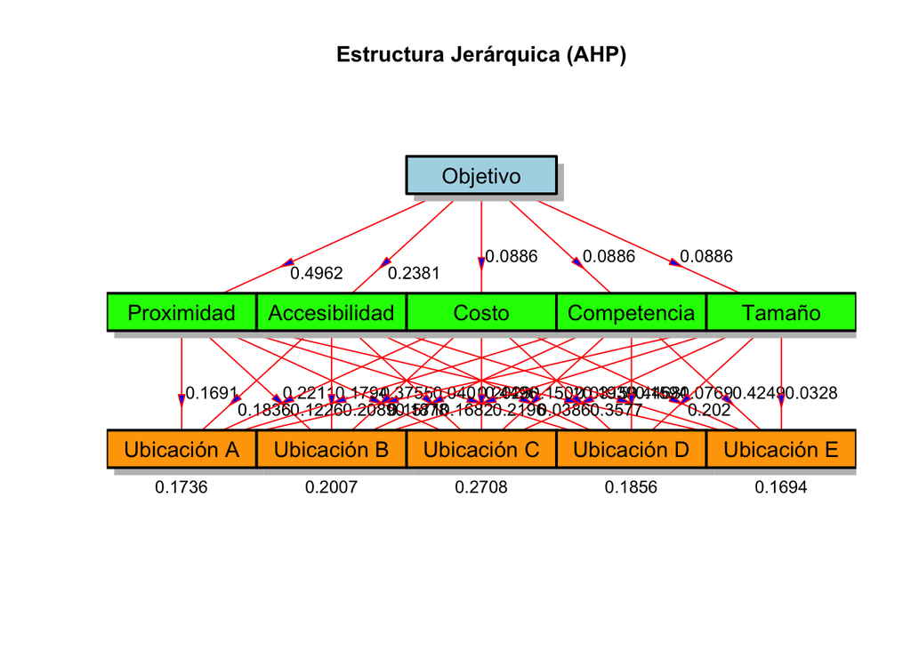

```r
tabla1 <- criterios2
tabla2 <- array(NA,dim = c(5,5,5))
tabla2[,,1] <- proximidad2
tabla2[,,2] <- accesibilidad2
tabla2[,,3] <- costo2
tabla2[,,4] <- competencia2
tabla2[,,5] <- tamano2
dimnames(tabla2)[[1]] <- alternativas
dimnames(tabla2)[[2]] <- alternativas
dimnames(tabla2)[[3]] <- criterios
multicriterio.metodoahp.diagrama(tabla1, tabla2)
```

Podemos ver que como en el resto de los métodos, la mejor ubicación es la C.

2. **Calcular las ponderaciones asociadas a cada criterio manejado.**

```r
pesos_criterios = multicriterio.metodoAHP.variante3.basico(criterios2)
pesos_criterios
```

```
## $Xmat
##               Proximidad Accesibilidad Costo Competencia Tamaño
## Proximidad     1.0000000     3.0000000     5           5      5
## Accesibilidad  0.3333333     1.0000000     3           3      3
## Costo          0.2000000     0.3333333     1           1      1
## Competencia    0.2000000     0.3333333     1           1      1
## Tamaño         0.2000000     0.3333333     1           1      1
##
## $sumacolumnas
##    Proximidad Accesibilidad         Costo   Competencia        Tamaño
##      1.933333      5.000000     11.000000     11.000000     11.000000
##
## $Xmat.normalizada
##               Proximidad Accesibilidad      Costo Competencia     Tamaño
## Proximidad     0.5172414    0.60000000 0.45454545  0.45454545 0.45454545
## Accesibilidad  0.1724138    0.20000000 0.27272727  0.27272727 0.27272727
## Costo          0.1034483    0.06666667 0.09090909  0.09090909 0.09090909
## Competencia    0.1034483    0.06666667 0.09090909  0.09090909 0.09090909
## Tamaño         0.1034483    0.06666667 0.09090909  0.09090909 0.09090909
##
## $valoraciones.ahp
##    Proximidad Accesibilidad         Costo   Competencia        Tamaño
##    0.49617555    0.23811912    0.08856844    0.08856844    0.08856844
##
## $valoraciones.ahp.ordenadas
##    Proximidad Accesibilidad         Costo   Competencia        Tamaño
##    0.49617555    0.23811912    0.08856844    0.08856844    0.08856844
##
## $tablaresumen
##               Proximidad Accesibilidad Costo Competencia Tamaño Proximidad
## Proximidad     1.0000000     3.0000000     5           5      5  0.5172414
## Accesibilidad  0.3333333     1.0000000     3           3      3  0.1724138
## Costo          0.2000000     0.3333333     1           1      1  0.1034483
## Competencia    0.2000000     0.3333333     1           1      1  0.1034483
## Tamaño         0.2000000     0.3333333     1           1      1  0.1034483
##                1.9333333     5.0000000    11          11     11         NA
##               Accesibilidad      Costo Competencia     Tamaño
## Proximidad       0.60000000 0.45454545  0.45454545 0.45454545
## Accesibilidad    0.20000000 0.27272727  0.27272727 0.27272727
## Costo            0.06666667 0.09090909  0.09090909 0.09090909
## Competencia      0.06666667 0.09090909  0.09090909 0.09090909
## Tamaño           0.06666667 0.09090909  0.09090909 0.09090909
##                          NA         NA          NA         NA
##               prioridades.relativas
## Proximidad               0.49617555
## Accesibilidad            0.23811912
## Costo                    0.08856844
## Competencia              0.08856844
## Tamaño                   0.08856844
##                                  NA
```

```r
pproximidad=  multicriterio.metodoAHP.variante3.basico(proximidad2)
pproximidad
```

```
## $Xmat
##             Ubicación A Ubicación B Ubicación C Ubicación D Ubicación E
## Ubicación A   1.0000000   5.0000000   0.2000000   0.1428571           3
## Ubicación B   0.2000000   1.0000000   0.3333333   5.0000000           7
## Ubicación C   5.0000000   3.0000000   1.0000000   3.0000000           9
## Ubicación D   7.0000000   0.2000000   0.3333333   1.0000000           5
## Ubicación E   0.3333333   0.1428571   0.1111111   0.2000000           1
##
## $sumacolumnas
## Ubicación A Ubicación B Ubicación C Ubicación D Ubicación E
##   13.533333    9.342857    1.977778    9.342857   25.000000
##
## $Xmat.normalizada
##             Ubicación A Ubicación B Ubicación C Ubicación D Ubicación E
## Ubicación A  0.07389163  0.53516820  0.10112360  0.01529052        0.12
## Ubicación B  0.01477833  0.10703364  0.16853933  0.53516820        0.28
## Ubicación C  0.36945813  0.32110092  0.50561798  0.32110092        0.36
## Ubicación D  0.51724138  0.02140673  0.16853933  0.10703364        0.20
## Ubicación E  0.02463054  0.01529052  0.05617978  0.02140673        0.04
##
## $valoraciones.ahp
## Ubicación A Ubicación B Ubicación C Ubicación D Ubicación E
##  0.16909479  0.22110390  0.37545559  0.20284421  0.03150151
##
## $valoraciones.ahp.ordenadas
## Ubicación C Ubicación B Ubicación D Ubicación A Ubicación E
##  0.37545559  0.22110390  0.20284421  0.16909479  0.03150151
##
## $tablaresumen
##             Ubicación A Ubicación B Ubicación C Ubicación D Ubicación E
## Ubicación A   1.0000000   5.0000000   0.2000000   0.1428571           3
## Ubicación B   0.2000000   1.0000000   0.3333333   5.0000000           7
## Ubicación C   5.0000000   3.0000000   1.0000000   3.0000000           9
## Ubicación D   7.0000000   0.2000000   0.3333333   1.0000000           5
## Ubicación E   0.3333333   0.1428571   0.1111111   0.2000000           1
##              13.5333333   9.3428571   1.9777778   9.3428571          25
##             Ubicación A Ubicación B Ubicación C Ubicación D Ubicación E
## Ubicación A  0.07389163  0.53516820  0.10112360  0.01529052        0.12
## Ubicación B  0.01477833  0.10703364  0.16853933  0.53516820        0.28
## Ubicación C  0.36945813  0.32110092  0.50561798  0.32110092        0.36
## Ubicación D  0.51724138  0.02140673  0.16853933  0.10703364        0.20
## Ubicación E  0.02463054  0.01529052  0.05617978  0.02140673        0.04
##                      NA          NA          NA          NA          NA
##             prioridades.relativas
## Ubicación A            0.16909479
## Ubicación B            0.22110390
## Ubicación C            0.37545559
## Ubicación D            0.20284421
## Ubicación E            0.03150151
##                                NA
```

```r
paccesibilidad=  multicriterio.metodoAHP.variante3.basico(accesibilidad2)
paccesibilidad
```

```
## $Xmat
##             Ubicación A Ubicación B Ubicación C Ubicación D Ubicación E
## Ubicación A   1.0000000   0.2000000           3   7.0000000   0.3333333
## Ubicación B   5.0000000   1.0000000           3   0.2000000   0.2000000
## Ubicación C   0.3333333   0.3333333           1   0.3333333   0.1111111
## Ubicación D   0.1428571   5.0000000           3   1.0000000   0.1428571
## Ubicación E   3.0000000   5.0000000           9   7.0000000   1.0000000
##
## $sumacolumnas
## Ubicación A Ubicación B Ubicación C Ubicación D Ubicación E
##    9.476190   11.533333   19.000000   15.533333    1.787302
##
## $Xmat.normalizada
##             Ubicación A Ubicación B Ubicación C Ubicación D Ubicación E
## Ubicación A  0.10552764  0.01734104  0.15789474  0.45064378  0.18650089
## Ubicación B  0.52763819  0.08670520  0.15789474  0.01287554  0.11190053
## Ubicación C  0.03517588  0.02890173  0.05263158  0.02145923  0.06216696
## Ubicación D  0.01507538  0.43352601  0.15789474  0.06437768  0.07992895
## Ubicación E  0.31658291  0.43352601  0.47368421  0.45064378  0.55950266
##
## $valoraciones.ahp
## Ubicación A Ubicación B Ubicación C Ubicación D Ubicación E
##  0.18358162  0.17940284  0.04006708  0.15016055  0.44678792
##
## $valoraciones.ahp.ordenadas
## Ubicación E Ubicación A Ubicación B Ubicación D Ubicación C
##  0.44678792  0.18358162  0.17940284  0.15016055  0.04006708
##
## $tablaresumen
##             Ubicación A Ubicación B Ubicación C Ubicación D Ubicación E
## Ubicación A   1.0000000   0.2000000           3   7.0000000   0.3333333
## Ubicación B   5.0000000   1.0000000           3   0.2000000   0.2000000
## Ubicación C   0.3333333   0.3333333           1   0.3333333   0.1111111
## Ubicación D   0.1428571   5.0000000           3   1.0000000   0.1428571
## Ubicación E   3.0000000   5.0000000           9   7.0000000   1.0000000
##               9.4761905  11.5333333          19  15.5333333   1.7873016
##             Ubicación A Ubicación B Ubicación C Ubicación D Ubicación E
## Ubicación A  0.10552764  0.01734104  0.15789474  0.45064378  0.18650089
## Ubicación B  0.52763819  0.08670520  0.15789474  0.01287554  0.11190053
## Ubicación C  0.03517588  0.02890173  0.05263158  0.02145923  0.06216696
## Ubicación D  0.01507538  0.43352601  0.15789474  0.06437768  0.07992895
## Ubicación E  0.31658291  0.43352601  0.47368421  0.45064378  0.55950266
##                      NA          NA          NA          NA          NA
##             prioridades.relativas
## Ubicación A            0.18358162
## Ubicación B            0.17940284
## Ubicación C            0.04006708
## Ubicación D            0.15016055
## Ubicación E            0.44678792
##                                NA
```

Ubicación E es la más preferida, ya que tiene la mayor puntuación global en el análisis.

```r
pcosto=  multicriterio.metodoAHP.variante3.basico(costo2)
pcosto
```

```
## $Xmat
##             Ubicación A Ubicación B Ubicación C Ubicación D Ubicación E
## Ubicación A   1.0000000   3.0000000   0.3333333   0.2000000   0.3333333
## Ubicación B   0.3333333   1.0000000   0.2000000   3.0000000   5.0000000
## Ubicación C   3.0000000   5.0000000   1.0000000   5.0000000   9.0000000
## Ubicación D   5.0000000   0.3333333   0.2000000   1.0000000   7.0000000
## Ubicación E   3.0000000   0.2000000   0.1111111   0.1428571   1.0000000
##
## $sumacolumnas
## Ubicación A Ubicación B Ubicación C Ubicación D Ubicación E
##   12.333333    9.533333    1.844444    9.342857   22.333333
##
## $Xmat.normalizada
##             Ubicación A Ubicación B Ubicación C Ubicación D Ubicación E
## Ubicación A  0.08108108  0.31468531  0.18072289  0.02140673  0.01492537
## Ubicación B  0.02702703  0.10489510  0.10843373  0.32110092  0.22388060
## Ubicación C  0.24324324  0.52447552  0.54216867  0.53516820  0.40298507
## Ubicación D  0.40540541  0.03496503  0.10843373  0.10703364  0.31343284
## Ubicación E  0.24324324  0.02097902  0.06024096  0.01529052  0.04477612
##
## $valoraciones.ahp
## Ubicación A Ubicación B Ubicación C Ubicación D Ubicación E
##  0.12256428  0.15706748  0.44960814  0.19385413  0.07690597
##
## $valoraciones.ahp.ordenadas
## Ubicación C Ubicación D Ubicación B Ubicación A Ubicación E
##  0.44960814  0.19385413  0.15706748  0.12256428  0.07690597
##
## $tablaresumen
##             Ubicación A Ubicación B Ubicación C Ubicación D Ubicación E
## Ubicación A   1.0000000   3.0000000   0.3333333   0.2000000   0.3333333
## Ubicación B   0.3333333   1.0000000   0.2000000   3.0000000   5.0000000
## Ubicación C   3.0000000   5.0000000   1.0000000   5.0000000   9.0000000
## Ubicación D   5.0000000   0.3333333   0.2000000   1.0000000   7.0000000
## Ubicación E   3.0000000   0.2000000   0.1111111   0.1428571   1.0000000
##              12.3333333   9.5333333   1.8444444   9.3428571  22.3333333
##             Ubicación A Ubicación B Ubicación C Ubicación D Ubicación E
## Ubicación A  0.08108108  0.31468531  0.18072289  0.02140673  0.01492537
## Ubicación B  0.02702703  0.10489510  0.10843373  0.32110092  0.22388060
## Ubicación C  0.24324324  0.52447552  0.54216867  0.53516820  0.40298507
## Ubicación D  0.40540541  0.03496503  0.10843373  0.10703364  0.31343284
## Ubicación E  0.24324324  0.02097902  0.06024096  0.01529052  0.04477612
##                      NA          NA          NA          NA          NA
##             prioridades.relativas
## Ubicación A            0.12256428
## Ubicación B            0.15706748
## Ubicación C            0.44960814
## Ubicación D            0.19385413
## Ubicación E            0.07690597
##                                NA
```

la Ubicación C es la opción más preferida, ya que tiene la puntuación más alta en el análisis global de costo.

```r
pcompetencia=  multicriterio.metodoAHP.variante3.basico(competencia2)
pcompetencia
```

```
## $Xmat
##             Ubicación A Ubicación B Ubicación C Ubicación D Ubicación E
## Ubicación A   1.0000000   0.2000000           3   9.0000000   0.3333333
## Ubicación B   5.0000000   1.0000000           3   0.1428571   0.1428571
## Ubicación C   0.3333333   0.3333333           1   0.3333333   0.1111111
## Ubicación D   0.1111111   7.0000000           3   1.0000000   0.2000000
## Ubicación E   3.0000000   7.0000000           9   5.0000000   1.0000000
##
## $sumacolumnas
## Ubicación A Ubicación B Ubicación C Ubicación D Ubicación E
##    9.444444   15.533333   19.000000   15.476190    1.787302
##
## $Xmat.normalizada
##             Ubicación A Ubicación B Ubicación C Ubicación D Ubicación E
## Ubicación A  0.10588235  0.01287554  0.15789474 0.581538462  0.18650089
## Ubicación B  0.52941176  0.06437768  0.15789474 0.009230769  0.07992895
## Ubicación C  0.03529412  0.02145923  0.05263158 0.021538462  0.06216696
## Ubicación D  0.01176471  0.45064378  0.15789474 0.064615385  0.11190053
## Ubicación E  0.31764706  0.45064378  0.47368421 0.323076923  0.55950266
##
## $valoraciones.ahp
## Ubicación A Ubicación B Ubicación C Ubicación D Ubicación E
##  0.20893840  0.16816878  0.03861807  0.15936383  0.42491093
##
## $valoraciones.ahp.ordenadas
## Ubicación E Ubicación A Ubicación B Ubicación D Ubicación C
##  0.42491093  0.20893840  0.16816878  0.15936383  0.03861807
##
## $tablaresumen
##             Ubicación A Ubicación B Ubicación C Ubicación D Ubicación E
## Ubicación A   1.0000000   0.2000000           3   9.0000000   0.3333333
## Ubicación B   5.0000000   1.0000000           3   0.1428571   0.1428571
## Ubicación C   0.3333333   0.3333333           1   0.3333333   0.1111111
## Ubicación D   0.1111111   7.0000000           3   1.0000000   0.2000000
## Ubicación E   3.0000000   7.0000000           9   5.0000000   1.0000000
##               9.4444444  15.5333333          19  15.4761905   1.7873016
##             Ubicación A Ubicación B Ubicación C Ubicación D Ubicación E
## Ubicación A  0.10588235  0.01287554  0.15789474 0.581538462  0.18650089
## Ubicación B  0.52941176  0.06437768  0.15789474 0.009230769  0.07992895
## Ubicación C  0.03529412  0.02145923  0.05263158 0.021538462  0.06216696
## Ubicación D  0.01176471  0.45064378  0.15789474 0.064615385  0.11190053
## Ubicación E  0.31764706  0.45064378  0.47368421 0.323076923  0.55950266
##                      NA          NA          NA          NA          NA
##             prioridades.relativas
## Ubicación A            0.20893840
## Ubicación B            0.16816878
## Ubicación C            0.03861807
## Ubicación D            0.15936383
## Ubicación E            0.42491093
##                                NA
```

```r
ptamaño=  multicriterio.metodoAHP.variante3.basico(tamano2)
ptamaño
```

```
## $Xmat
##             Ubicación A Ubicación B Ubicación C Ubicación D Ubicación E
## Ubicación A   1.0000000   5.0000000   0.3333333         0.2           3
## Ubicación B   0.2000000   1.0000000   0.3333333         5.0           7
## Ubicación C   3.0000000   3.0000000   1.0000000         3.0           9
## Ubicación D   5.0000000   0.2000000   0.3333333         1.0           5
## Ubicación E   0.3333333   0.1428571   0.1111111         0.2           1
##
## $sumacolumnas
## Ubicación A Ubicación B Ubicación C Ubicación D Ubicación E
##    9.533333    9.342857    2.111111    9.400000   25.000000
##
## $Xmat.normalizada
##             Ubicación A Ubicación B Ubicación C Ubicación D Ubicación E
## Ubicación A  0.10489510  0.53516820  0.15789474   0.0212766        0.12
## Ubicación B  0.02097902  0.10703364  0.15789474   0.5319149        0.28
## Ubicación C  0.31468531  0.32110092  0.47368421   0.3191489        0.36
## Ubicación D  0.52447552  0.02140673  0.15789474   0.1063830        0.20
## Ubicación E  0.03496503  0.01529052  0.05263158   0.0212766        0.04
##
## $valoraciones.ahp
## Ubicación A Ubicación B Ubicación C Ubicación D Ubicación E
##  0.18784693  0.21956446  0.35772388  0.20203199  0.03283275
##
## $valoraciones.ahp.ordenadas
## Ubicación C Ubicación B Ubicación D Ubicación A Ubicación E
##  0.35772388  0.21956446  0.20203199  0.18784693  0.03283275
##
## $tablaresumen
##             Ubicación A Ubicación B Ubicación C Ubicación D Ubicación E
## Ubicación A   1.0000000   5.0000000   0.3333333         0.2           3
## Ubicación B   0.2000000   1.0000000   0.3333333         5.0           7
## Ubicación C   3.0000000   3.0000000   1.0000000         3.0           9
## Ubicación D   5.0000000   0.2000000   0.3333333         1.0           5
## Ubicación E   0.3333333   0.1428571   0.1111111         0.2           1
##               9.5333333   9.3428571   2.1111111         9.4          25
##             Ubicación A Ubicación B Ubicación C Ubicación D Ubicación E
## Ubicación A  0.10489510  0.53516820  0.15789474   0.0212766        0.12
## Ubicación B  0.02097902  0.10703364  0.15789474   0.5319149        0.28
## Ubicación C  0.31468531  0.32110092  0.47368421   0.3191489        0.36
## Ubicación D  0.52447552  0.02140673  0.15789474   0.1063830        0.20
## Ubicación E  0.03496503  0.01529052  0.05263158   0.0212766        0.04
##                      NA          NA          NA          NA          NA
##             prioridades.relativas
## Ubicación A            0.18784693
## Ubicación B            0.21956446
## Ubicación C            0.35772388
## Ubicación D            0.20203199
## Ubicación E            0.03283275
##                                NA
```

Ubicación C es la más adecuada en términos de tamaño, con una valoración superior lo que indica que podría ofrecer una ventaja significativa por sus dimensiones o espacio disponible.

4.**Determina la consistencia general.**

```r
consistencia=multicriterio.metodoAHP.coef.inconsistencia(criterios2)
consistencia
```

```
## $lambda
## [1] 5.041959
##
## $m
## [1] 5
##
## $CI.coef.inconsistencia
## [1] 0.01048987
##
## $CA.aleatorio
## [1] 1.12
##
## $RI.coef.inconsistencia
## [1] 0.009365954
##
## $mensaje
## [1] "Consistencia aceptable"
```

5. **Determinar la prioridad global de cada ubicación.**

```r
 multicriterio.metodoAHP.pesosglobales_entabla(pesos_criterios$valoraciones.ahp,                                         rbind(pproximidad$valoraciones.ahp,
                                                          paccesibilidad$valoraciones.ahp,
                                                          pcosto$valoraciones.ahp,
                                                          pcompetencia$valoraciones.ahp,
                                                          ptamaño$valoraciones.ahp))
```

```
##                  Proximidad Accesibilidad      Costo Competencia     Tamaño
## Ubicación A      0.16909479    0.18358162 0.12256428  0.20893840 0.18784693
## Ubicación B      0.22110390    0.17940284 0.15706748  0.16816878 0.21956446
## Ubicación C      0.37545559    0.04006708 0.44960814  0.03861807 0.35772388
## Ubicación D      0.20284421    0.15016055 0.19385413  0.15936383 0.20203199
## Ubicación E      0.03150151    0.44678792 0.07690597  0.42491093 0.03283275
## Ponder.Criterios 0.49617555    0.23811912 0.08856844  0.08856844 0.08856844
##                  Ponderadores Globales
## Ubicación A                  0.1736130
## Ubicación B                  0.2006777
## Ubicación C                  0.2707571
## Ubicación D                  0.1855801
## Ubicación E                  0.1693721
## Ponder.Criterios                    NA
```